# Coursera Prediction Assignment (predmachlearn-013)

E. Bradley

April 25, 2015

## EXECUTIVE SUMMARY

In this report, we analyzed the Weight Lifting Exercise (WLE) Dataset from Groupware@LES (http://groupware.les.inf.puc-rio.br/har). This dataset includes measurements from four accelerometers (on the arm, forearm, belt, and dumbbell) for six participants as they performed one set of 10 repetitions of the Unilateral Dumbbell Biceps Curl with five different variations: exactly according to the specification (Class A), throwing the elbows to the front (Class B), lifting the dumbbell only halfway (Class C), lowering the dumbbell only halfway (Class D) and throwing the hips to the front (Class E). The objective for this research is to predict the quality (class) for a weight-lifting exercise based solely on accelerometer measurements. In this project, we utilized a Random Forest model on 48 variables. This model correctly predicted the 20 outcomes from the blind test set. The cross-validation accuracy was 99.53% (on the 25% of the original training set that was put aside for cross-validation). The out-of-bagging (OOB) estimate of the error rate was 0.43%, which is very close to the out-of-sample error rate for our cross-validation set (100% - accuracy = 0.47%).

WLE Dataset Paper: http://groupware.les.inf.puc-rio.br/har#wle_paper_section#ixzz3YRYzrXJv

Dataset citation:  
Velloso, E.; Bulling, A.; Gellersen, H.; Ugulino, W.; Fuks, H. Qualitative Activity Recognition of Weight Lifting Exercises. Proceedings of 4th International Conference in Cooperation with SIGCHI (Augmented Human ’13) . Stuttgart, Germany: ACM SIGCHI, 2013.

## ANALYSIS

### Exploratory Analysis & Preprocessing

In this dataset, there were 19622 observations and 160 variables. We excluded aggregate variables, given that in our test set we were only provided with timestamp not time window summary observations. These variables were identified by searching for columns which were predominantly NA’s or “” (specifically which had these values for 19216 of the 19622 observations and only had valid data for 406 observations where it was a “new_window”). Examples of these aggregate variables were “kurtosis_roll_arm” and “max_roll_dumbbell”. We also excluded the first seven columns, which were metadata for the observations (index, participant name, timestamps, and time window designations) as these should not inform a general predictive model. Lastly, we excluded four variables due to their high correlation (absolute value better than 0.95) with other variables. The correlation matrix for the data preceding this step is shown in **Fig. 1** for the first 15 variables.

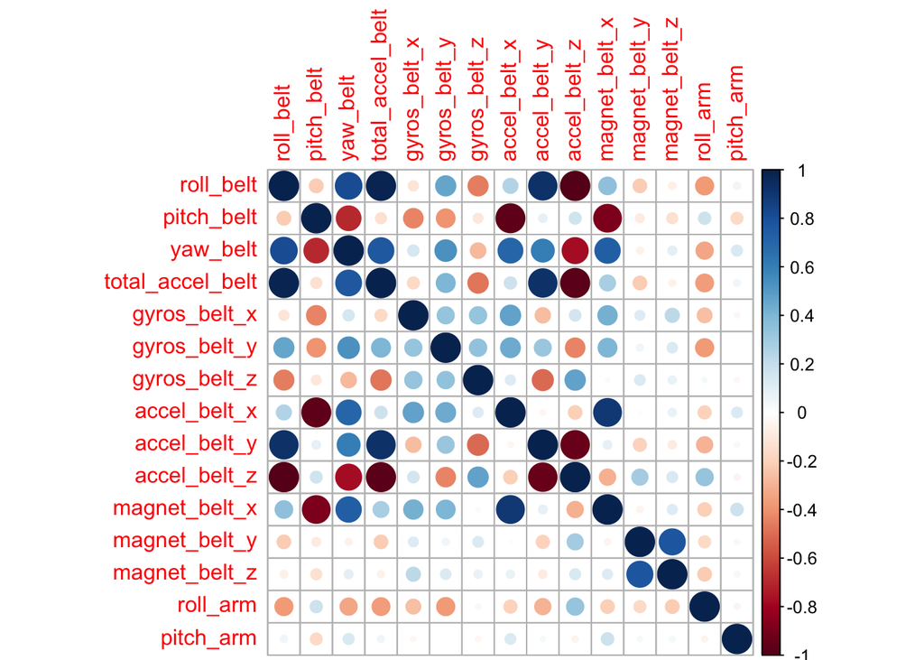

To further explore the data, we also plotted some of the different variables colored by the classe variable (outcome). As shown here, there is some variation apparent for the roll belt variable and the outcome (particularly for extremes for D and E).

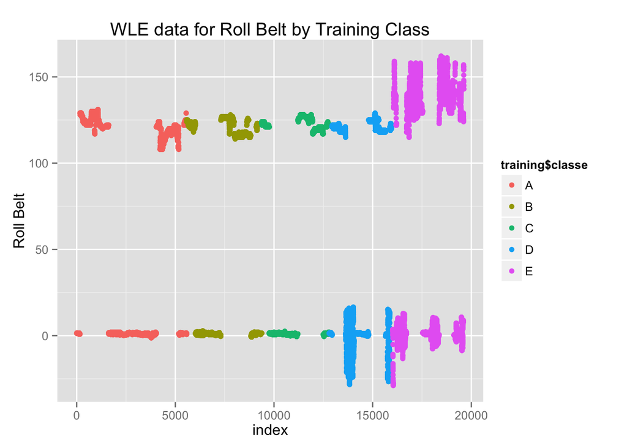

### Model Selection

We first implemented a simple decision tree to get a sense of the data and then implemented a Random Forest model, given that it is one of the most accurate and widely used prediction models. In R, the randomForest implements Breiman’s random forest algorithm (based on Breiman and Cutler’s original Fortran code) for classification and regression. For this, we used the default settings. A Random Forest model utilizes ensemble trees with bootstrap aggregating (bagging). Bagging takes a randomized sample of the observations in the training set, with replacement. Additionally Random Forests utilize different subsets of the available variables for each tree. For a given input, each tree makes a classification and the average of these will be the output prediction from the Random Forest model. So although each individual tree overfits, the ensemble average is a good predictor.

For cross-validation, we split the original training set into a training set (75%) and a test set (25%).

For a simple decision tree, as shown below, we saw that the decision tree split on four variables, including roll belt. However, this single decision tree did not perform well. In cross-validation, it only had an accuracy of 49%.

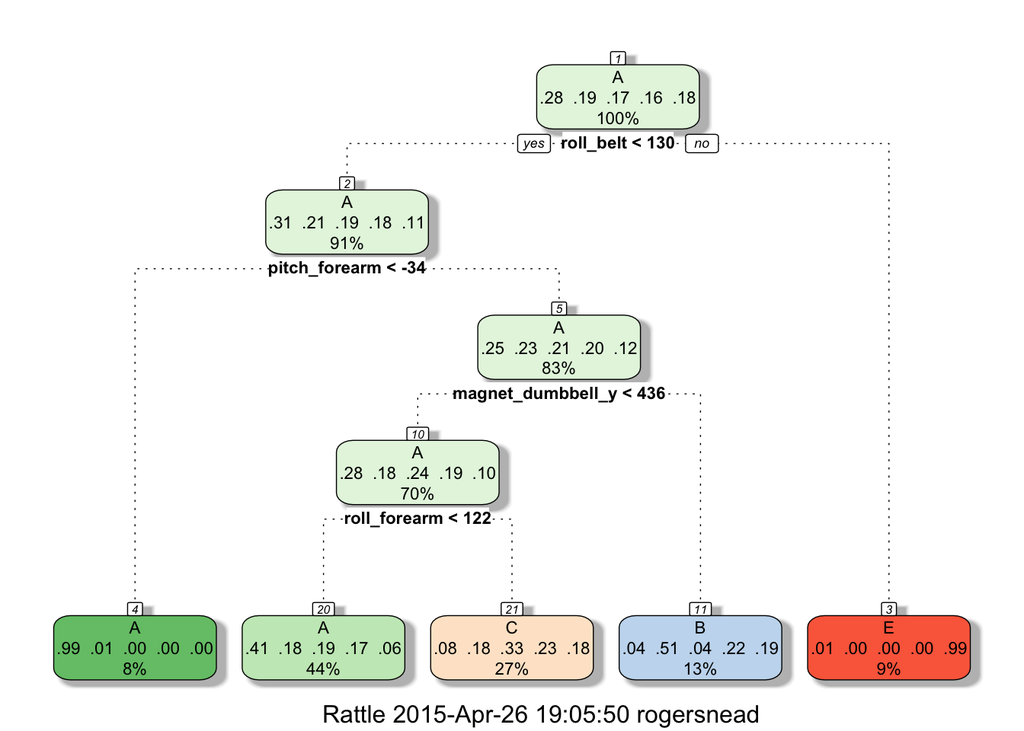

Results for the decision tree on the cross-validation test set:

```r
confusionMatrix(test$classe,predict(mod_simple,test))
```

```
## Confusion Matrix and Statistics
##
##           Reference
## Prediction    A    B    C    D    E
##          A 1275   25   92    0    3
##          B  404  309  236    0    0
##          C  374   28  453    0    0
##          D  357  153  294    0    0
##          E  130  131  266    0  374
##
## Overall Statistics
##
##                Accuracy : 0.4916
##                  95% CI : (0.4776, 0.5057)
##     No Information Rate : 0.5179
##     P-Value [Acc > NIR] : 0.9999
##
##                   Kappa : 0.3358
##  Mcnemar's Test P-Value : NA
##
## Statistics by Class:
##
##                      Class: A Class: B Class: C Class: D Class: E
## Sensitivity            0.5020  0.47833  0.33781       NA  0.99204
## Specificity            0.9492  0.84969  0.88717   0.8361  0.88359
## Pos Pred Value         0.9140  0.32561  0.52982       NA  0.41509
## Neg Pred Value         0.6395  0.91479  0.78069       NA  0.99925
## Prevalence             0.5179  0.13173  0.27345   0.0000  0.07688
## Detection Rate         0.2600  0.06301  0.09237   0.0000  0.07626
## Detection Prevalence   0.2845  0.19352  0.17435   0.1639  0.18373
## Balanced Accuracy      0.7256  0.66401  0.61249       NA  0.93781
```

## Final Model Results

Implementing the Random Forest algorithm (with default 500 trees) had much better results. The cross-validation accuracy was 99.53% (on the 25% of the original training set that was put aside for cross-validation) and it correctly predicted the outcome for all 20 of the observations in the original blind test set. The out-of-bagging (OOB) estimate of the error rate was 0.43%, which is very close to the out-of-sample error rate for our cross-validation set (100% - accuracy = 0.47%).

```r
print(mod)
```

```
##
## Call:
##  randomForest(formula = classe ~ ., data = train)
##                Type of random forest: classification
##                      Number of trees: 500
## No. of variables tried at each split: 6
##
##         OOB estimate of  error rate: 0.43%
## Confusion matrix:
##      A    B    C    D    E  class.error
## A 4183    2    0    0    0 0.0004778973
## B   13 2831    4    0    0 0.0059691011
## C    0   13 2552    2    0 0.0058433970
## D    0    0   22 2388    2 0.0099502488
## E    0    0    1    4 2701 0.0018477458
```

Confusion matrix for cross-validation test set -

```r
confusionMatrix(test$classe,predict(mod,test))
```

```
## Confusion Matrix and Statistics
##
##           Reference
## Prediction    A    B    C    D    E
##          A 1394    0    0    0    1
##          B    3  945    1    0    0
##          C    0    3  848    4    0
##          D    0    0    7  796    1
##          E    0    0    0    3  898
##
## Overall Statistics
##
##                Accuracy : 0.9953
##                  95% CI : (0.993, 0.997)
##     No Information Rate : 0.2849
##     P-Value [Acc > NIR] : < 2.2e-16
##
##                   Kappa : 0.9941
##  Mcnemar's Test P-Value : NA
##
## Statistics by Class:
##
##                      Class: A Class: B Class: C Class: D Class: E
## Sensitivity            0.9979   0.9968   0.9907   0.9913   0.9978
## Specificity            0.9997   0.9990   0.9983   0.9980   0.9993
## Pos Pred Value         0.9993   0.9958   0.9918   0.9900   0.9967
## Neg Pred Value         0.9991   0.9992   0.9980   0.9983   0.9995
## Prevalence             0.2849   0.1933   0.1746   0.1637   0.1835
## Detection Rate         0.2843   0.1927   0.1729   0.1623   0.1831
## Detection Prevalence   0.2845   0.1935   0.1743   0.1639   0.1837
## Balanced Accuracy      0.9988   0.9979   0.9945   0.9947   0.9985
```

As shown in the variable importance plot, one of the most important variables is roll_belt.

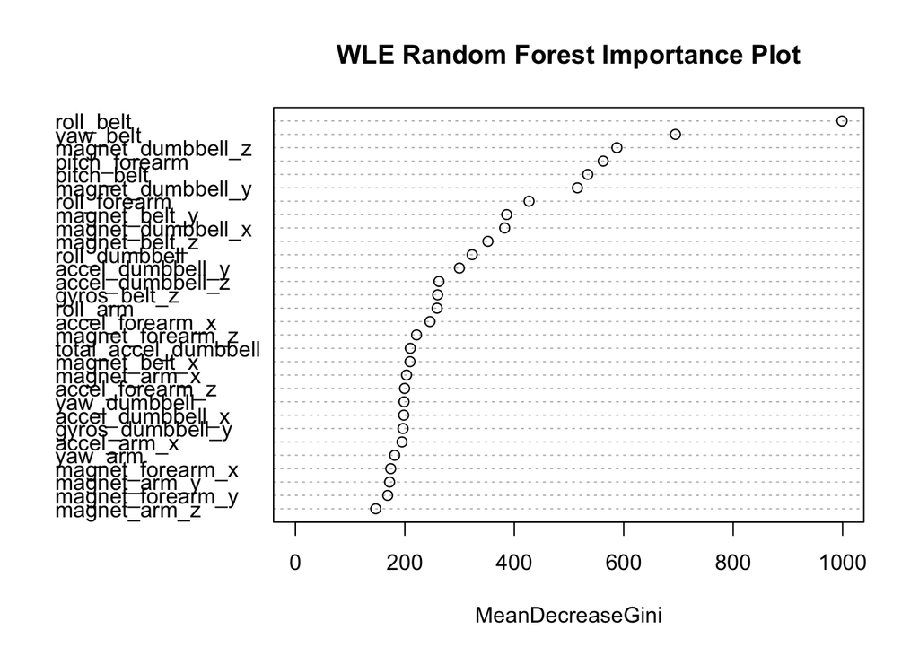